# Quality Control: Filtering & Trimming Amplicon Sequences

Ezra Seckin

April 17, 2026

# Goals of this file

**NOTE:** This document was **NOT** run during class. Instead, it is building off of what we covered in class to help move the learning along for lab next week. We will start at the error modeling step in lab next week.

0. Load packages and prepare for fastq files.
1. Use raw fastq files and generate quality plots to assess quality of raw reads.
2. Evaluate whether primers are present in the sequences.
3. Filter and trim out primers, bad sequences and bases from the sequencing files.
4. Assess if filtering and trimming was adequate. If not, re-run with new parameters.
5. Write out fastq files with high quality sequences.
6. Evaluate the quality from the filter and trim step and whether it is adequate.

Output that we will create in this file:

1. Quality plots to asses pre- and post-quality trimming.
2. Written files that include the filtered and trimmed data. (Note that this will be written during the `filterAndTrim()` function.)

# Setting up the environment

### Set the seed

Why is it useful to set a seed?

1. *Reproducibility*:
   - If you’re using random number generation (e.g., bootstrapping, simulations, machine learning models), setting a seed ensures that you (and others) can get the same results every time you run the code.
2. *Debugging & Collaboration*:
   - If your analysis involves randomness (e.g., shuffling datasets, training ML models), setting a seed makes it easier to debug and compare results across different runs or machines.
   - Colleagues can run your code and get identical results, making scientific collaboration more reliable.
3. *Benchmarking & Model Comparisons*:
   - In machine learning, setting a seed ensures that models trained with random splits of data or initial weights are comparable across different trials.
   - If you don’t set a seed, each run might give slightly different performance metrics, making it harder to evaluate true differences between models.
4. *Avoiding Accidental Bias in Random Sampling*:
   - When selecting random subsets of data (e.g., cross-validation splits), setting a seed ensures that all experiments are based on the same random selection, reducing unwanted variability.

```r
# Any number can be chosen
set.seed(238428)
```

### Timing of Script

```r
# What time did we start running this script?
start_time <- Sys.time()
start_time
```

```
## [1] "2026-04-17 00:53:15 EDT"
```

# Load Libraries

```r
# Efficient package loading with pacman
pacman::p_load(tidyverse, dada2, patchwork,
               DT, devtools, Biostrings, ShortRead,
               install = FALSE)
```

# 0. Prepare Raw fastq Files

```r
# Set the raw fastq path to the raw sequencing files
# Path to the fastq files
raw_fastqs_path <- "data/00_raw_gzipped_fastqs"
raw_fastqs_path
```

```
## [1] "data/00_raw_gzipped_fastqs"
```

```r
# What files are in this path? Intuition Check
head(list.files(raw_fastqs_path))
```

```
## [1] "SRR3666998_1.fastq.gz" "SRR3666998_2.fastq.gz" "SRR3666999_1.fastq.gz"
## [4] "SRR3666999_2.fastq.gz" "SRR3667000_1.fastq.gz" "SRR3667000_2.fastq.gz"
```

```r
# How many files are there?
length(list.files(raw_fastqs_path))
```

```
## [1] 86
```

```r
# Create vector of forward reads
forward_reads <- list.files(raw_fastqs_path, pattern = "_1.fastq.gz", full.names = TRUE)

# Intuition Checks
head(forward_reads)
```

```
## [1] "data/00_raw_gzipped_fastqs/SRR3666998_1.fastq.gz"
## [2] "data/00_raw_gzipped_fastqs/SRR3666999_1.fastq.gz"
## [3] "data/00_raw_gzipped_fastqs/SRR3667000_1.fastq.gz"
## [4] "data/00_raw_gzipped_fastqs/SRR3667001_1.fastq.gz"
## [5] "data/00_raw_gzipped_fastqs/SRR3667002_1.fastq.gz"
## [6] "data/00_raw_gzipped_fastqs/SRR3667003_1.fastq.gz"
```

```r
# Intuition check #2: We should have fewer reads in the forward vector than in total
#stopifnot(length(forward_reads) < length(list.files(raw_fastqs_path)))

# Create a vector of reverse reads
reverse_reads <- list.files(raw_fastqs_path, pattern = "_2.fastq.gz", full.names = TRUE)

# Intuition Checks
head(reverse_reads)
```

```
## [1] "data/00_raw_gzipped_fastqs/SRR3666998_2.fastq.gz"
## [2] "data/00_raw_gzipped_fastqs/SRR3666999_2.fastq.gz"
## [3] "data/00_raw_gzipped_fastqs/SRR3667000_2.fastq.gz"
## [4] "data/00_raw_gzipped_fastqs/SRR3667001_2.fastq.gz"
## [5] "data/00_raw_gzipped_fastqs/SRR3667002_2.fastq.gz"
## [6] "data/00_raw_gzipped_fastqs/SRR3667003_2.fastq.gz"
```

```r
# Intuition check #2: Need to have equal number of forward and reverse files
#stopifnot(length(reverse_reads) == length(forward_reads))
```

# 1. Assess Raw Read Quality

## Evaluate raw sequence quality

Let’s see the quality of the raw reads *before* we trim

## Plot 12 random samples of plots

```r
# Randomly select 12 samples from dataset to evaluate
# Selecting 12 is typically better than 2 (like we did in class for efficiency)
random_samples <- sample(1:length(reverse_reads), size = 12)
random_samples
```

```
##  [1] 40 16 39 28  4  8 38  5 30  3 42 43
```

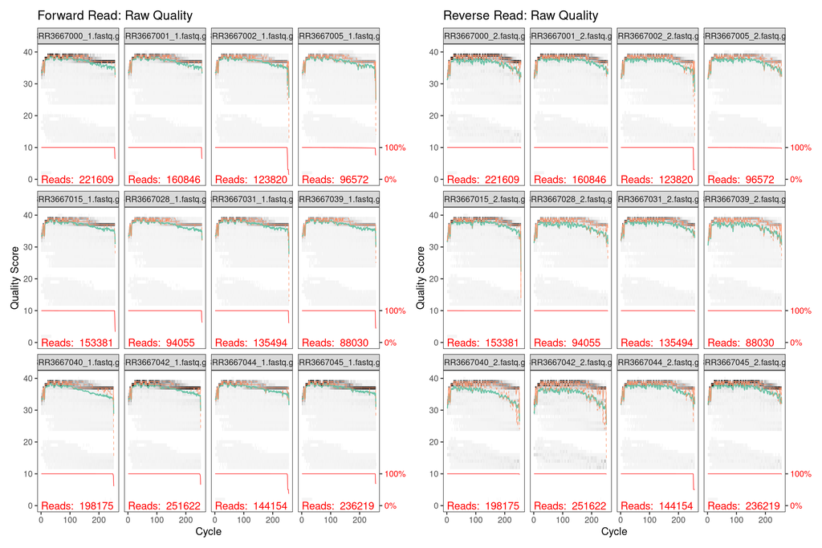

```r
# Calculate and plot quality of these two samples
forward_filteredQual_plot_12 <- plotQualityProfile(forward_reads[random_samples]) +
  labs(title = "Forward Read: Raw Quality")
reverse_filteredQual_plot_12 <- plotQualityProfile(reverse_reads[random_samples]) +
  labs(title = "Reverse Read: Raw Quality")

# Plot them together with patchwork
forward_filteredQual_plot_12 + reverse_filteredQual_plot_12
```

**REMEMBER:** If you have NextSeq data, your quality scores will be binned, instead of having the 40 integer phred scores. This is ok!

**Acceptable Phred Scores for ASVs with DADA2**

In DADA2, quality filtering is crucial for obtaining reliable biological sequences. Below are the acceptable **Phred score** thresholds for DADA2 preprocessing:

| **Q Score** | **Error Probability** | **DADA2 Interpretation** |
| --- | --- | --- |
| **40** | 0.0001 (1 in 10,000) | Very high-quality , dream come true |
| **≥30** | ≤ 0.001 (1 in 1,000) | Excellent quality, keep |
| **25-30** | ~0.003 - 0.01 | Can be acceptable, but more important to trim low-quality tails |
| **20-25** | ~0.01 - 0.03 | Lower quality, only acceptable if read length is absolutely critical |
| **<20** | > 0.01 (1 in 100) | Poor quality, remove |
| **<10** | >0.1 (1 in 10) | Very unreliable, absolutely remove |

Some summary take-aways:

- **30 is good** – Bases with Q30+ scores have a **99.9% accuracy rate**, making them highly reliable.
- **25-30 can be acceptable**, but trimming is preferred to remove low-quality tails.
- **20-25** should only be kept if read length is absolutely critical (*e.g.* to ensure forward & reverse read overlap)
- **<20 discarded** – Bases with Phred scores below 20 have an **error rate >1%** and should 100% be **trimmed from the dataset**.

Remember, every base counts when we assign ASVs, they are called **sequence variants** for a reason! And, we want to be sure. :)

## Aggregated Raw Quality Plots

Next, we will plot all of the samples aggregated into one forward (left) and one reverse read (right) plot.

> **WARNING:** This step takes a long time and depends on both the depth of sequencing and the number of samples. Therefore, it could be helpful to start writing up your answer based off of the 12 samples above.

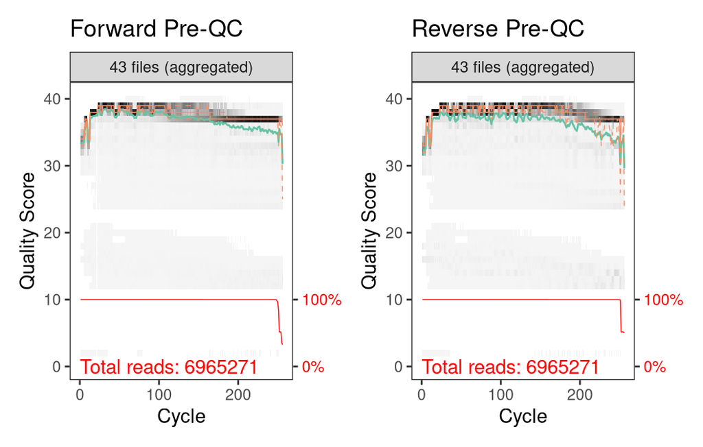

```r
# Aggregate all QC plots
# Forward reads
forward_preQC_plot <-
  plotQualityProfile(forward_reads, aggregate = TRUE) +
  labs(title = "Forward Pre-QC")

# reverse reads
reverse_preQC_plot <-
  plotQualityProfile(reverse_reads, aggregate = TRUE) +
  labs(title = "Reverse Pre-QC")

# Now, let's put the two plots together
preQC_aggregate_plot <-
  # Plot the forward and reverse together
  forward_preQC_plot + reverse_preQC_plot
# Show the plot
preQC_aggregate_plot
```

INTERPRETATION #1 of Pre-QC: Here, in this location of your analyses, please insert a description of the interpretation you draw regarding your plots. You must note anything important about the figure you’ve created about your data including any spikes in quality and also the general trend of the raw QC plots. An example is provided below.

Above are plots showing the pre-QC quality scores of the raw sequencing data for the project. We can draw a few conclusions from the plots above, which were generated with 2x250 bp sequencing on an Illumina MiSeq Sequencer:

General notes on Illumina sequencing

- **Forward & Reverse Reads:**
  - Typically all reads decline in quality over the sequencing run due to phasing (*i.e.* when the clusters become out of sync with each other later in the run).
  - Read quality at the beginning of the read can be common due to primer/adapter sequence artifacts
- **Reverse Reads Quality is generally lower because:**
  - Sequencing of the reverse reads happens second, after chemistry degrades a bit after sequencing the forward reads.
  - Physical flipping of the sequence is required.
  - Phasing errors are enhanced, more accumulated errors.
  - Optical strength is weaker compared to the first sequencing, leading to more miscalls.

# 2. Evaluate Primer Search

> Does your dataset include primers?

However, if the standard Illumina 2-step PCR library prep was used, **then primers will be included in the sequences and they will need to be trimmed out of the sequences later.**

Please be sure to use the primer sequences that were used for your project’s dataset, which should be located in the method’s section! If you need help finding these, please be welcome to come to office hours and/or email Mar for help.

Now, let’s check for those primers!

```r
# Search the sequences for primers to check if they are present
# Pull out the raw_fastq sequences from all of the raw sequencing files
raw_fastqs <- readFastq(dirPath = raw_fastqs_path)
# The above code makes a complex S3 object.Let's only grab the DNA sequences
all_seqs <- sread(raw_fastqs)

# The primer sequences that were used for the in class dataset.
# NOTE: YOU WILL NEED TO MODIFY THE CODE TO MATCH THE PRIMERS USED IN YOUR DATASET!
f_primer <- c("NNNNCCTACGGGNGGCWGCAG")
r_primer <- c("GACTACHVGGGTATCTAATCC")
f_primer_len <- nchar(f_primer)
r_primer_len <- nchar(r_primer)

# Search the dataset
# Check the complement of the primers....
Fprimer_complement <- complement(DNAString(f_primer))
Fprimer_revComplement <- reverseComplement(DNAString(f_primer))

Rprimer_complement <- complement(DNAString(r_primer))
Rprimer_revComplement <- reverseComplement(DNAString(r_primer))

# Test an example on one sequence randomly selected from a forward read fastq file
test_DNAseq <- DNAString("GGTCCCTACGGGTGGCAGCAGTGGGGAATATTGGACAATGGACCAAAAGTCTGATCCAGC…")

# Test code now
matchPattern(pattern = "ANAGA", # Part of the test seq with degeneracy
             subject = test_DNAseq,
             # NOTE: fixed MUST = FALSE because the primers have degeneracy
             fixed = FALSE)
```

```
## Views on a 251-letter DNAString subject
## subject: GGTCCCTACGGGTGGCAGCAGTGGGGAATATTGG...GCGCGTCTAGGCGGTTTAGTAAGTCTGATGTGAA
## views:
##       start end width
##   [1]   134 138     5 [ACAGA]
```

```r
############ POSITIVE CONTROLS OF CODE TO MAKE SURE IT WORKS ############
# Let's use a sequence that is very conserved and def present
# Postive control intuition check
pos_control <-
  vcountPattern(pattern = "CGGAATTACTGGGCG", # This is a pattern that I know is in the sequences
                subject = all_seqs,
                fixed = FALSE)

# Make a note :)
paste("Positive control is found in", round(sum(pos_control)/length(all_seqs) * 100, digits = 2),
      "% of sequences")
```

```
## [1] "Positive control is found in 9.78 % of sequences"
```

```r
# When there is a match, vmatchPattern can be used to locate the indices of the matches
test_pos_control <-
  vmatchPattern(pattern = "CGGAATTACTGGGCG",
                subject = all_seqs,
                fixed = FALSE)

# Take a look
head(test_pos_control)
```

```
## MIndex object of length 6
## [[1]]
## IRanges object with 0 ranges and 0 metadata columns:
##        start       end     width
##    <integer> <integer> <integer>
##
## [[2]]
## IRanges object with 0 ranges and 0 metadata columns:
##        start       end     width
##    <integer> <integer> <integer>
##
## [[3]]
## IRanges object with 1 range and 0 metadata columns:
##           start       end     width
##       <integer> <integer> <integer>
##   [1]       198       212        15
##
## ...
## <3 more elements>
```

```r
# And double check the degenerate nucleotides are ok within these functions, too
pos_degen_control <-
  vcountPattern(pattern = "GTGYC",
                subject = all_seqs,
                fixed = FALSE)

# Make a note :)
paste("Positive control with a degenerate base is found in", round(sum(pos_degen_control)/length(all_seqs) * 100, digits = 2),
      "% of sequences")
```

```
## [1] "Positive control with a degenerate base is found in 70.25 % of sequences"
```

```r
stopifnot(sum(pos_degen_control) > round(sum(pos_control)))
```

Now, let’s specifically test for the **forward** primers:

```r
############ FORWARD PRIMERS ############
# Now, let's search the sequences for the primers
# Search first for forward primer
Fprimer_vmatch <-
  vcountPattern(pattern = f_primer,
                subject = all_seqs,
                fixed = FALSE);
# Note:
paste("The forward primer is found in", round(sum(Fprimer_vmatch)/length(all_seqs) * 100, digits = 2),
      "% of sequences")
```

```
## [1] "The forward primer is found in 48.63 % of sequences"
```

```r
# Then double check with complement of forward primer
Fprimer_complement_vmatch <-
  vcountPattern(pattern = Fprimer_complement,
                subject = all_seqs,
                fixed = FALSE);
# Note:
paste("The complement of the forward primer is found in", round(sum(Fprimer_complement_vmatch)/length(all_seqs) * 100, digits = 2),
      "% of sequences")
```

```
## [1] "The complement of the forward primer is found in 0.08 % of sequences"
```

Great, now let’s specifically test for the **reverse** primers:

```r
############ REVERSE PRIMERS ############
# Now, let's search for the reverse primer
Rprimer_vmatch <-
  vcountPattern(pattern = r_primer,
                subject = all_seqs,
                fixed = FALSE);
paste("The reverse primer is found in", round(sum(Rprimer_vmatch)/length(all_seqs) * 100, digits = 2),
      "% of sequences")
```

```
## [1] "The reverse primer is found in 47.74 % of sequences"
```

```r
# Then double check with complement of forward primer
Rprimer_complement_vmatch <-
  vcountPattern(pattern = Rprimer_complement,
                subject = all_seqs,
                fixed = FALSE);
paste("The complement of reverse primer is found in", round(sum(Rprimer_complement_vmatch)/length(all_seqs) * 100, digits = 2),
      "% of sequences")
```

```
## [1] "The complement of reverse primer is found in 0.08 % of sequences"
```

# 3. Filter and Trim

## A. Prepare a placeholder for filtered reads

```r
# Create vector of sample names from the filenames
sample_names <- sapply(strsplit(basename(forward_reads), "_"), `[`,1)

# Intuition Check
head(sample_names)
```

```
## [1] "SRR3666998" "SRR3666999" "SRR3667000" "SRR3667001" "SRR3667002"
## [6] "SRR3667003"
```

```r
# Place filtered reads into filtered_fastqs_path
filtered_fastqs_path <- "data/01_QualityTrimming/filtered_fastqs"

# Intuition Check
filtered_fastqs_path
```

```
## [1] "data/01_QualityTrimming/filtered_fastqs"
```

```r
# create 2 vectors: filtered_forward_reads & filtered_reverse_reads
filtered_forward_reads <-
  file.path(filtered_fastqs_path, paste0(sample_names, "_R1_filtered.fastq.gz"))

# Intuition Check
length(filtered_forward_reads)
```

```
## [1] 43
```

```r
# reverse reads
filtered_reverse_reads <-
  file.path(filtered_fastqs_path, paste0(sample_names, "_R2_filtered.fastq.gz"))

# Intuition Check
head(filtered_reverse_reads)
```

```
## [1] "data/01_QualityTrimming/filtered_fastqs/SRR3666998_R2_filtered.fastq.gz"
## [2] "data/01_QualityTrimming/filtered_fastqs/SRR3666999_R2_filtered.fastq.gz"
## [3] "data/01_QualityTrimming/filtered_fastqs/SRR3667000_R2_filtered.fastq.gz"
## [4] "data/01_QualityTrimming/filtered_fastqs/SRR3667001_R2_filtered.fastq.gz"
## [5] "data/01_QualityTrimming/filtered_fastqs/SRR3667002_R2_filtered.fastq.gz"
## [6] "data/01_QualityTrimming/filtered_fastqs/SRR3667003_R2_filtered.fastq.gz"
```

## B. Actually Filter and Trim Reads

Parameters of filter and trim **DEPEND ON THE DATASET AND SEQUENCING RUN**. If your sequences are run on multiple sequencing runs, you will need to run these separately!!! I recommended making parallel processes (either in separate files or back-to-back in a single file for each sequencing run).

Some things to keep in mind are:

- The library preparation: *Are the primers included in the sequence? If so, they need to be trimmed out in this step*. (Please follow the code above to assess for the primers and use the output from that here!)
- What do the above quality profiles of the reads look like? *If they are lower quality, it is highly recommended to use `maxEE = c(1,1)`.*
- Do the reads dip suddenly in their quality? If so, explore `trimLeft` and `truncLen`
- Check out more of the parameters using `?filterAndTrim` to bring up the help page and do some googling about it.

Some notes on two examples are below, with a description of a few of the parameters:

Important parameters in `filterAndTrim()` to be aware of:

- `maxEE` is a quality filtering threshold applied to expected errors. Here, if there’s 2 expected errors. It’s ok. But more than 2. Throw away the sequence. Two values, first is for forward reads; second is for reverse reads. If your read quality is generally lower than this dataset, I recommended you use `maxEE = c(1,1)`.
- `trimLeft` can be used to remove the beginning bases of a read (e.g. to trim out primers!)
- `truncLen` can be used to trim your sequences after a specific base pair when the quality gets lower. Though, please note that **this will shorten the ASVs**! For example, this can be used when the quality of the sequence suddenly gets lower, or clearly is typically lower. So, if the quality of the read drops below a phred score of 25 (on the y-axis of the plotQualityProfile above, which indicates ~99.5% confidence per base).
- `maxN` the number of N bases. Here, using ASVs, we should ALWAYS remove all Ns from the data.

```r
# ── 0. Set environment and verify Cutadapt ───────────────────────────────────
# Set PYTHONPATH so R can find the Cutadapt installation
Sys.setenv(PYTHONPATH = "/programs/cutadapt-5.1/lib/python3.9/site-packages:/programs/cutadapt-5.1/lib64/python3.9/site-packages")

# Set the correct path to the Cutadapt binary
cutadapt_path <- "/programs/cutadapt-5.1/bin/cutadapt"

# Verify it works — should print "5.1"
system2(cutadapt_path, args = "--version", stdout = TRUE, stderr = TRUE)
```

```
## [1] "5.1"
```

```r
# ── 1. Define primers ─────────────────────────────────────────────────────────
f_primer    <- "NNNNCCTACGGGNGGCWGCAG"
r_primer    <- "GACTACHVGGGTATCTAATCC"
f_primer_rc <- toString(reverseComplement(DNAString(f_primer)))
r_primer_rc <- toString(reverseComplement(DNAString(r_primer)))

# ── 2. Create output directories ──────────────────────────────────────────────
primer_trimmed_path <- "data/01_QualityTrimming/primer_trimmed_fastqs"
untrimmed_path      <- "data/01_QualityTrimming/untrimmed_fastqs"

for (p in c(primer_trimmed_path, untrimmed_path)) {
  if (!dir.exists(p)) dir.create(p, recursive = TRUE)
}

# ── 3. Build output file path vectors ─────────────────────────────────────────
# Primer-trimmed reads (primers detected and removed) → fed into filterAndTrim()
primer_trimmed_forward <- file.path(primer_trimmed_path,
                                    paste0(sample_names, "_R1_primertrimmed.fastq.gz"))
primer_trimmed_reverse <- file.path(primer_trimmed_path,
                                    paste0(sample_names, "_R2_primertrimmed.fastq.gz"))

# Untrimmed reads (no primer detected) → saved for inspection, NOT used downstream
untrimmed_forward <- file.path(untrimmed_path,
                               paste0(sample_names, "_R1_untrimmed.fastq.gz"))
untrimmed_reverse <- file.path(untrimmed_path,
                               paste0(sample_names, "_R2_untrimmed.fastq.gz"))

# ── 4. Run Cutadapt on every sample ───────────────────────────────────────────
# Key flags:
#   -g / -G                       5′ primer on R1 / R2
#   -a / -A                       3′ read-through RC primer on R1 / R2
#   --untrimmed-output            where to write R1 reads with NO primer found
#   --untrimmed-paired-output     where to write R2 reads with NO primer found
#   -m 50                         discard reads shorter than 50 bp after trimming
#   --overlap 10                  minimum primer overlap to call a match
#   -j 0                          auto-detect cores

cutadapt_results <- vector("list", length(sample_names))

for (i in seq_along(sample_names)) {

  cutadapt_args <- c(
    "-g", f_primer,
    "-a", r_primer_rc,
    "-G", r_primer,
    "-A", f_primer_rc,
    "--untrimmed-output",        untrimmed_forward[i],   # R1 rejects
    "--untrimmed-paired-output", untrimmed_reverse[i],   # R2 rejects
    "-m",       "50",
    "--overlap", "10",
    "-j",       "0",
    "-o", primer_trimmed_forward[i],
    "-p", primer_trimmed_reverse[i],
    forward_reads[i],
    reverse_reads[i]
  )

  cutadapt_results[[i]] <- system2(cutadapt_path,
                                    args   = cutadapt_args,
                                    stdout = TRUE,
                                    stderr = TRUE)
}

# ── 5. Sanity checks ──────────────────────────────────────────────────────────
stopifnot(all(file.exists(primer_trimmed_forward)))
stopifnot(all(file.exists(primer_trimmed_reverse)))
cat("✓ Primer-trimmed files written to:", primer_trimmed_path, "\n")
```

```
## ✓ Primer-trimmed files written to: data/01_QualityTrimming/primer_trimmed_fastqs
```

```r
cat("✓ Untrimmed (no primer found) files written to:", untrimmed_path, "\n")
```

```
## ✓ Untrimmed (no primer found) files written to: data/01_QualityTrimming/untrimmed_fastqs
```

```r
# How many untrimmed reads were there per sample? (useful for QC reporting)
untrimmed_counts <- sapply(untrimmed_forward, function(f) {
  if (file.exists(f) && file.size(f) > 0) length(readFastq(f)) else 0L
})
names(untrimmed_counts) <- sample_names
cat("\nUntrimmed read counts per sample:\n")
```

```
##
## Untrimmed read counts per sample:
```

```r
print(untrimmed_counts)
```

```
## SRR3666998 SRR3666999 SRR3667000 SRR3667001 SRR3667002 SRR3667003 SRR3667004
##       2876       1264       2644       1437        980       1117       3312
## SRR3667005 SRR3667006 SRR3667007 SRR3667010 SRR3667011 SRR3667012 SRR3667013
##       3524        750       2117       1557       1381       1434       1898
## SRR3667014 SRR3667015 SRR3667016 SRR3667017 SRR3667018 SRR3667020 SRR3667021
##       2220       1442       1805       1825       1044       1996       1652
## SRR3667022 SRR3667023 SRR3667024 SRR3667025 SRR3667026 SRR3667027 SRR3667028
##       2238       2214       1479       2089       2040       1126        942
## SRR3667029 SRR3667031 SRR3667032 SRR3667033 SRR3667034 SRR3667035 SRR3667036
##       1049       1524       1704        800       3974        998       1122
## SRR3667037 SRR3667038 SRR3667039 SRR3667040 SRR3667042 SRR3667043 SRR3667044
##       1464       1242       1037       2529       4423       3004       1148
## SRR3667045
##       2268
```

```r
# ── 6. Filter & Trim quality for primer-trimmed reads ─────────────────────────
# NOTE: trimLeft is NOT used here — Cutadapt already removed the primers above.
# Adjust truncLen based on your quality plots.
filtered_reads <-
  filterAndTrim(primer_trimmed_forward, filtered_forward_reads,
                primer_trimmed_reverse, filtered_reverse_reads,
                truncLen    = c(228, 225),  # ← since our sequences are shorter, we do 230-2 and 230-5
                maxN        = 0,
                maxEE       = c(2, 2),
                truncQ      = 2,
                rm.phix     = TRUE,
                compress    = TRUE,
                multithread = 10)

# ── 7. Filter & Trim quality for untrimmed (no primer found) reads ─────────────
# Define output paths for quality-filtered untrimmed reads
filtered_fastqs_path_untrimmed <- "data/01_QualityTrimming/filtered_fastqs_untrimmed"
if (!dir.exists(filtered_fastqs_path_untrimmed)) {
  dir.create(filtered_fastqs_path_untrimmed, recursive = TRUE)
}

filtered_untrimmed_forward <- file.path(filtered_fastqs_path_untrimmed,
                                        paste0(sample_names, "_R1_filtered_untrimmed.fastq.gz"))
filtered_untrimmed_reverse <- file.path(filtered_fastqs_path_untrimmed,
                                        paste0(sample_names, "_R2_filtered_untrimmed.fastq.gz"))

filtered_untrimmed_reads <-
  filterAndTrim(untrimmed_forward, filtered_untrimmed_forward,
                untrimmed_reverse, filtered_untrimmed_reverse,
                truncLen    = c(248, 245),  # ← can differ from primer-trimmed if needed
                maxN        = 0,
                maxEE       = c(2, 2),
                truncQ      = 2,
                rm.phix     = TRUE,
                compress    = TRUE,
                multithread = 10)
```

## D. Plot Filtered & Trimmed Read Quality of Subset of Samples

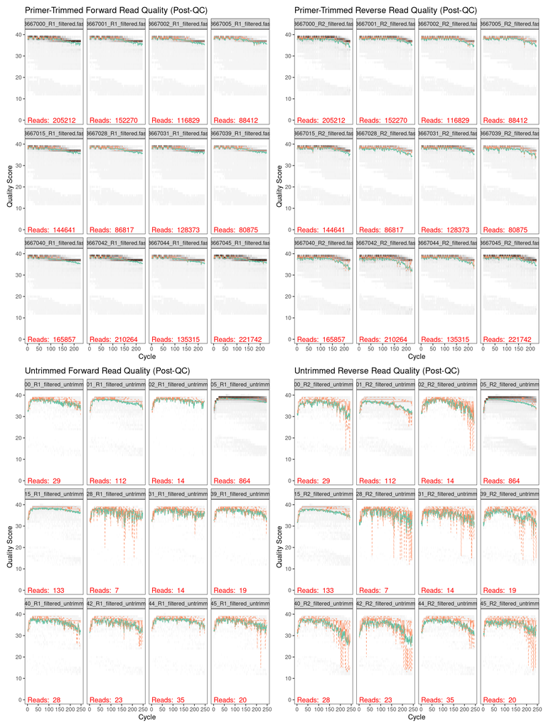

```r
# ── Primer-trimmed filtered reads ─────────────────────────────────────────────
forward_filteredQual_plot_12 <-
  plotQualityProfile(filtered_forward_reads[random_samples]) +
  labs(title = "Primer-Trimmed Forward Read Quality (Post-QC)")

reverse_filteredQual_plot_12 <-
  plotQualityProfile(filtered_reverse_reads[random_samples]) +
  labs(title = "Primer-Trimmed Reverse Read Quality (Post-QC)")

# ── Untrimmed (no primer found) filtered reads ────────────────────────────────
forward_untrimmed_filteredQual_plot_12 <-
  plotQualityProfile(filtered_untrimmed_forward[random_samples]) +
  labs(title = "Untrimmed Forward Read Quality (Post-QC)")

reverse_untrimmed_filteredQual_plot_12 <-
  plotQualityProfile(filtered_untrimmed_reverse[random_samples]) +
  labs(title = "Untrimmed Reverse Read Quality (Post-QC)")

# ── Plot all four together with patchwork ─────────────────────────────────────
# Arranged as two rows: primer-trimmed on top, untrimmed on bottom
(forward_filteredQual_plot_12 + reverse_filteredQual_plot_12) /
(forward_untrimmed_filteredQual_plot_12 + reverse_untrimmed_filteredQual_plot_12)
```

## E. Plot Aggregated Filtered & Trimmed Plots of All Samples

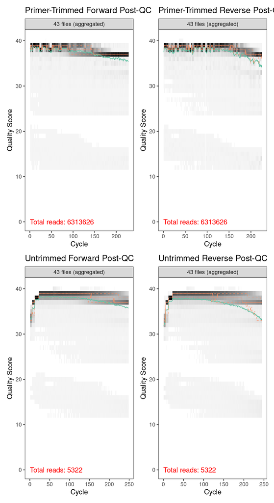

```r
# ── Primer-trimmed filtered reads (aggregated) ────────────────────────────────
forward_postQC_plot <-
  plotQualityProfile(filtered_forward_reads, aggregate = TRUE) +
  labs(title = "Primer-Trimmed Forward Post-QC")

reverse_postQC_plot <-
  plotQualityProfile(filtered_reverse_reads, aggregate = TRUE) +
  labs(title = "Primer-Trimmed Reverse Post-QC")

# ── Untrimmed (no primer found) filtered reads (aggregated) ───────────────────
forward_untrimmed_postQC_plot <-
  plotQualityProfile(filtered_untrimmed_forward, aggregate = TRUE) +
  labs(title = "Untrimmed Forward Post-QC")

reverse_untrimmed_postQC_plot <-
  plotQualityProfile(filtered_untrimmed_reverse, aggregate = TRUE) +
  labs(title = "Untrimmed Reverse Post-QC")

# ── Plot all four together with patchwork ─────────────────────────────────────
# Arranged as two rows: primer-trimmed on top, untrimmed on bottom
(forward_postQC_plot + reverse_postQC_plot) /
(forward_untrimmed_postQC_plot + reverse_untrimmed_postQC_plot)
```

## F. Save Filtered Reads Data

```r
# SAVE DATA FIRST
save(filtered_reads, file = "data/01_QualityTrimming/filtered_reads.RData")
```

# 4. Assess if filtering and trimming was adequate. If not, re-run with new parameters.

INTERPRETATION #3 of Post-QC: Here, in this location of your analyses, please insert a description of the interpretation you draw regarding your post filterAndTrim plots. Please note anything important about the figure you’ve created about your data generally speaking to your post-QC reads. What’s the general trend? In the next question, we will plot the pre- and post-QC togeter and compare them. The goal here is to evaluate the QC process. An example is provided below.

**Takeaway:** Quality filtering successfully retained high-quality bases while removing low-quality tails.

To further confirm that things look ok, let’s take a look at the read retention of our QC step.

### A. Read Retention Post-QC

```r
# Make output into dataframe
filtered_df <- as.data.frame(filtered_reads) %>%
  mutate(percent.retained = reads.out/reads.in)

# Intuition check
# Visualize it in table format
DT::datatable(filtered_df)
```

|  | reads.in | reads.out | percent.retained |
| --- | --- | --- | --- |
| SRR3666998_R1_primertrimmed.fastq.gz | 253492 | 231005 | 0.9112910861092264 |
| SRR3666999_R1_primertrimmed.fastq.gz | 160909 | 154065 | 0.9574666426365213 |
| SRR3667000_R1_primertrimmed.fastq.gz | 218959 | 205212 | 0.9372165565242808 |
| SRR3667001_R1_primertrimmed.fastq.gz | 159384 | 152270 | 0.9553656577824625 |
| SRR3667002_R1_primertrimmed.fastq.gz | 122812 | 116829 | 0.9512832622219327 |
| SRR3667003_R1_primertrimmed.fastq.gz | 123854 | 113628 | 0.9174350444878647 |
| SRR3667004_R1_primertrimmed.fastq.gz | 258915 | 228714 | 0.8833555413938937 |
| SRR3667005_R1_primertrimmed.fastq.gz | 93005 | 88412 | 0.950615558303317 |
| SRR3667006_R1_primertrimmed.fastq.gz | 106573 | 100549 | 0.9434753643042797 |
| SRR3667007_R1_primertrimmed.fastq.gz | 196614 | 187893 | 0.955644053831365 |

[output cut: 33 more lines]

```r
# Let's calculate some statistics
read_stats_df <-
  filtered_df %>%
  reframe(median_reads_in = median(reads.in),
          median_reads_out = median(reads.out),
          median_percent_retained = (median(reads.out)/median(reads.in)),
          max_percent_retained = max(reads.out/reads.in),
          min_percent_retained = min(reads.out/reads.in))

# Take a look at it!
read_stats_df
```

```
##   median_reads_in median_reads_out median_percent_retained max_percent_retained
## 1          153859           140672               0.9142917            0.9679394
##   min_percent_retained
## 1            0.8424723
```

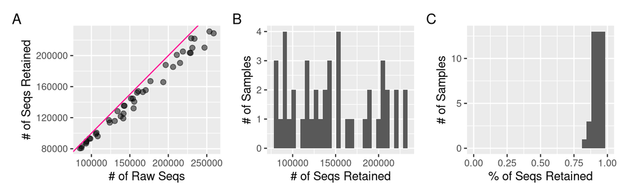

```r
# Plot it
numSeqs_QC_dotplot <-
  filtered_df %>%
  ggplot(aes(x = reads.in, y = reads.out)) +
  geom_point(alpha = 0.5, size = 2) +
  labs(x = "# of Raw Seqs",
       y = "# of Seqs Retained") +
  # Now let's add a 1:1 line for reference of keeping 100% of the reads
  geom_abline(slope=1, intercept = 0, color = "deeppink")

# Now, let's look at the number of reads retained in a histogram
numRetained_QC_histplot <-
  filtered_df %>%
  ggplot(aes(x = reads.out)) +
  geom_histogram() +
  labs(x = "# of Seqs Retained",
       y = "# of Samples")

# Create a histogram of percent reads retained in a histogram
percSeqs_QC_histplot <-
  filtered_df %>%
  ggplot(aes(x = percent.retained)) +
  geom_histogram() +
  labs(x = "% of Seqs Retained",
       y = "# of Samples") +
  # Set the scale to be between 0-1 (0-100%)
  scale_x_continuous(limits = c(0, 1))

# Now, let's put the plots together
numSeqs_QC_dotplot + numRetained_QC_histplot + percSeqs_QC_histplot +
  plot_annotation(tag_levels = 'A')
```

INTERPRETATION #4 of Post-QC Statistics: Here, in this location of your analyses, please insert a description of the interpretation you draw regarding your read retainment pre- and post-QC. Please note anything important about the three paneled figure you created above. Think about how many reads got through? Is it “enough”? Should I play with the parameters in `filterAndTrim()` more? If so, which parameters? An example interpretation is provided below.

This figure presents three panels showing how many sequences were retained after quality filtering and trimming in the DADA2 pipeline. Let’s break down each panel:

**Panel A: Scatter Plot of Raw vs. Retained Sequences:**

- X-axis: Number of raw sequences before filtering.
- Y-axis: Number of sequences retained after filtering.
- Pink Line: The diagonal line represents perfect retention (i.e., no sequences lost).

*Interpretation of Panel A:*

- Most points are close to the diagonal, meaning most samples retained a high proportion of reads.
- Some points fall below the line, indicating that a few samples lost more sequences during filtering.
- No extreme outliers, meaning no sample lost an excessive number of reads unexpectedly. Overall, good retention of reads across most samples. Minor losses are normal due to quality filtering.

**Panel B: Histogram of the Number of Sequences Retained per Sample**

- X-axis: Number of sequences retained per sample.
- Y-axis: Number of samples with that many retained sequences.

*Interpretation of Panel B*

**Panel C: Histogram of Percent of Sequences Retained**

- X-axis: Proportion (%) of sequences retained per sample.
- Y-axis: Number of samples at each proportion.

*Interpretation of Panel C*.

**Consider re-running your `filterAndTrim()` if:**

- If important samples lost too many reads, consider relaxing `maxEE` (expected errors) or adjusting truncation lengths (`truncLen`).
- Low merging success later on in the DADA2 workflow (suggests too much length variation).
- Reverse read degradation still affects error modeling (trim further if needed).

## B. Visualize QC differences Pre- and Post-Filering & Trimming

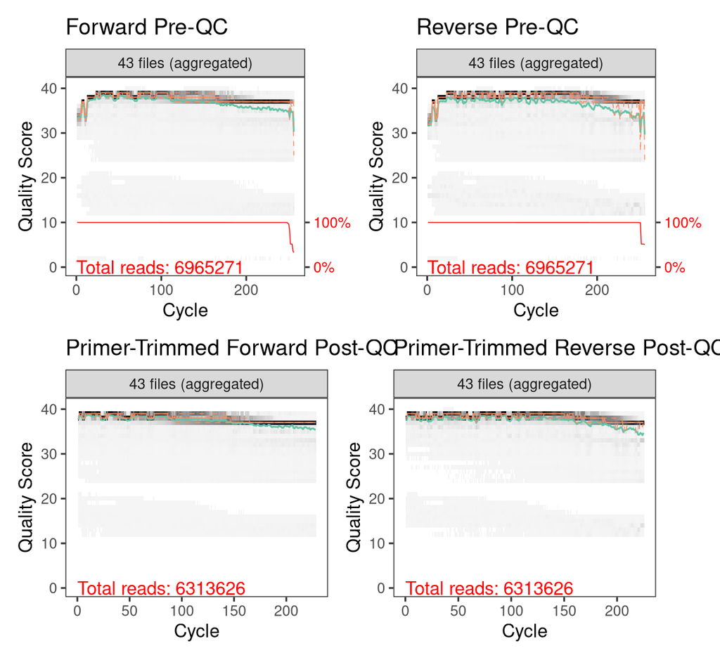

```r
# Plot the pre and post together in one plot
postQC_aggregate_plot <- forward_postQC_plot + reverse_postQC_plot
preQC_aggregate_plot / postQC_aggregate_plot
```

**Quality Score Improvements**

# Done with Analyses for now! :)

# Check Render Time

```r
# Take the time now that we are at the end of the script
end_time <- Sys.time()
end_time
```

```
## [1] "2026-04-17 01:16:22 EDT"
```

```r
# Echo the elapsed time
elapsed_time <- round((end_time - start_time), 3)
elapsed_time
```

```
## Time difference of 23.117 mins
```